```r
library(data.table)
library(ggplot2)
library(tidyr)
require(dplyr)
require(rpart)
require(caret)
require(TSrepr)
require(TSdist)
require(dtw)
require(TunePareto)
library(zoo)
require("logging")
require(stringr)
require(GGally)
require(rpart)
require(rattle)
```

# IE 48B Group Project Report

Şeyma Çakır, Ferhat Turhan

1/23/2022

# Introduction

In addition to the past data, a weather data including the hourly temperature data belonging to seven different locations close to the big cities in Turkey, downward shortwave radiation flux and some other relevant data is also provided. These cities are Antalya, Adana, Konya, İzmir, Eskişehir, Ankara and İstanbul respectively. However, some of the locations coincide with the outskirts of the cities, so they may not reflect the temperatures of the corresponding cities accurately. These data can be found [here](https://drive.google.com/drive/folders/1jDD7uOHDGNXdirZyv_ZwQAgJDp-FYis9?usp=sharing), which is updated daily by the instructor.

Before jumping directly to the prediction part, the data is represented in different ways and various distance approaches are used for k-nn classification. After finding the best representation for the imbalance data based on the k-nn classification using different types of distance measurements, tree-based regression approach is used for the next day's imbalance prediction.

# Related Literature

Time series representations are used for significant reduction of the time series dimensionality, emphasis on fundamental (essential) shape characteristics, implicit noise handling reducing and the dimension that will reduce memory requirements and computational complexity of consequent machine learning methods.() In this task, some of the representation techniques such as rpart representation, piecewise linear approximation and symbolic aggregate approximation are used. ([more](https://cran.r-project.org/web/packages/TSrepr/vignettes/TSrepr_representations_of_time_series.html))

SAX is the first symbolic representation for time series that allows for dimensionality reduction and indexing with a lower-bounding distance measure. In classic data mining tasks such as clustering, classification, index, etc., SAX is as good as well-known representations such as Discrete Wavelet Transform (DWT) and Discrete Fourier Transform (DFT), while requiring less storage space. ([more](https://cs.gmu.edu/~jessica/sax.htm)) SAX allows a time series of arbitrary length n to be reduced to a string of arbitrary length w, (w < n, typically w << n). The alphabet size is also an arbitrary integer a, where a > 2. ([more](https://www.cs.ucr.edu/~eamonn/SAX.pdf))

A piecewise linear approximation is one method of constructing a function g(x) that fits a nonlinear objective function f(x) by adding extra binary variables, continuous variables, and constraints to reformulate the original problem. The specific goal is to approximate a single valued function of one variable in terms of a sequence of linear segments. ([more](https://optimization.mccormick.northwestern.edu/index.php/Piecewise_linear_approximatio))

K-nearest neighbors (K-NN) algorithm is a type of supervised ML algorithm which can be used for both classification as well as regression predictive problems. K-nearest neighbors (KNN) algorithm uses ‘feature similarity’ to predict the values of new data points which further means that the new data point will be assigned a value based on how closely it matches the points in the training set. ([more](https://www.tutorialspoint.com/machine_learning_with_python/machine_learning_with_python_knn_algorithm_finding_nearest_neighbors.htm))

To predict the next day's imbalance signs tree-based regression trees are used. Tree-based regression models are known for their simplicity and efficiency when dealing with domains with large number of variables and cases. Regression trees are obtained using a fast divide and conquer greedy algorithm that recursively partitions the given training data into smaller subsets. By using this algorithm it is easier to decide on which variables will be put on the model or not. Since we used a linear regression model as the base model, we could choose our regressors by using the tree based regression model. ([more](https://www.dcc.fc.up.pt/~ltorgo/PhD/th3.pdf))

### Summary of Data

the data is readed and the example of data, structure of data, and the general statistics of system direction are shown below.

```r
# To avoid randomness in each run of code the randomness standardized.
setwd('C:\\Users\\seycakir\\Documents\\GitHub\\fall21-seymacakir\\Project')
set.seed(488)
```

```r
# Since data needs long process, the logging used for keep track of process.
basicConfig(level='FINEST')
addHandler(writeToFile, file="C:\\Users\\seycakir\\Documents\\GitHub\\fall21-seymacakir\\Project\\Logger.log", level='DEBUG')
```

```r
raw_data = fread('bulk_imbalance.csv')
#raw_data[c(1:5,(nrow(raw_data)-5):nrow(raw_data)),]
str(raw_data)
summary(as.factor(raw_data$system_direction))
tail(raw_data,30)
```

```
Classes 'data.table' and 'data.frame':	26832 obs. of  12 variables:
 $ date                   : IDate, format: "2019-01-01" "2019-01-01" ...
 $ hour                   : int  0 1 2 3 4 5 6 7 8 9 ...
 $ net                    : num  -1935 -751 -983 -765 -1233 ...
 $ upRegulationZeroCoded  : num  0 0 0 0 0 0 0 0 0 0 ...
 $ upRegulationOneCoded   : num  0 0 0 0 0 0 0 0 0 0 ...
 $ upRegulationTwoCoded   : int  0 0 0 0 0 0 0 0 0 0 ...
 $ downRegulationZeroCoded: num  2289 808 1061 1120 1875 ...
 $ downRegulationOneCoded : num  0 0 0 0 56 56 0 0 0 0 ...
 $ downRegulationTwoCoded : int  0 0 0 0 0 0 0 0 0 0 ...
 $ upRegulationDelivered  : num  0 0 0 0 0 0 0 0 0 0 ...
 $ downRegulationDelivered: num  -1935 -751 -983 -765 -1233 ...
 $ system_direction       : chr  "Negative" "Negative" "Negative" "Negative" ...
 - attr(*, ".internal.selfref")=<externalptr>
```

**1**

24

**Negative**

9408

**Neutral**

2421

**Positive**

14979

A data.table: 30 × 12

| date <date> | hour <int> | net <dbl> | upRegulationZeroCoded <dbl> | upRegulationOneCoded <dbl> | upRegulationTwoCoded <int> | downRegulationZeroCoded <dbl> | downRegulationOneCoded <dbl> | downRegulationTwoCoded <int> | upRegulationDelivered <dbl> | downRegulationDelivered <dbl> | system_direction <chr> |
| --- | --- | --- | --- | --- | --- | --- | --- | --- | --- | --- | --- |
| 2022-01-21 | 18 | 4161.272 | 4427.983 | 0 | 0 | 0.000 | 0 | 0 | 4161.272 | 0.000 | Positive |
| 2022-01-21 | 19 | 3967.694 | 4304.701 | 0 | 0 | 0.000 | 0 | 0 | 3967.694 | 0.000 | Positive |
| 2022-01-21 | 20 | 4519.441 | 4881.333 | 0 | 0 | 0.000 | 0 | 0 | 4519.441 | 0.000 | Positive |
| 2022-01-21 | 21 | 3549.844 | 3847.250 | 0 | 0 | 0.000 | 0 | 0 | 3549.844 | 0.000 | Positive |
| 2022-01-21 | 22 | 3907.912 | 4443.534 | 0 | 0 | 0.000 | 0 | 0 | 3907.912 | 0.000 | Positive |
| 2022-01-21 | 23 | 4660.870 | 5238.384 | 0 | 0 | 56.333 | 0 | 0 | 4717.203 | -56.333 | Positive |
| 2022-01-22 | 0 | 4500.204 | 5530.750 | 0 | 0 | 0.000 | 0 | 0 | 4500.204 | 0.000 |  |
| 2022-01-22 | 1 | 4687.520 | 5691.500 | 0 | 0 | 0.000 | 0 | 0 | 4687.520 | 0.000 |  |
| 2022-01-22 | 2 | 3819.368 | 4826.833 | 0 | 0 | 0.000 | 0 | 0 | 3819.368 | 0.000 |  |
| 2022-01-22 | 3 | 3075.214 | 4097.500 | 0 | 0 | 0.000 | 0 | 0 | 3075.214 | 0.000 |  |
| 2022-01-22 | 4 | 2522.163 | 3553.284 | 0 | 0 | 0.000 | 0 | 0 | 2522.163 | 0.000 |  |
| 2022-01-22 | 5 | 2696.979 | 3829.833 | 0 | 0 | 0.000 | 0 | 0 | 2696.979 | 0.000 |  |
| 2022-01-22 | 6 | 3018.599 | 4159.367 | 0 | 0 | 0.000 | 0 | 0 | 3018.599 | 0.000 |  |
| 2022-01-22 | 7 | 3725.378 | 4914.583 | 0 | 0 | 0.000 | 0 | 0 | 3725.378 | 0.000 |  |
| 2022-01-22 | 8 | 4338.125 | 5576.333 | 0 | 0 | 0.000 | 0 | 0 | 4338.125 | 0.000 |  |
| 2022-01-22 | 9 | 0.000 | 0.000 | 0 | 0 | 0.000 | 0 | 0 | 0.000 | 0.000 |  |
| 2022-01-22 | 10 | 0.000 | 0.000 | 0 | 0 | 0.000 | 0 | 0 | 0.000 | 0.000 |  |
| 2022-01-22 | 11 | 0.000 | 0.000 | 0 | 0 | 0.000 | 0 | 0 | 0.000 | 0.000 |  |
| 2022-01-22 | 12 | 0.000 | 0.000 | 0 | 0 | 0.000 | 0 | 0 | 0.000 | 0.000 |  |
| 2022-01-22 | 13 | 0.000 | 0.000 | 0 | 0 | 0.000 | 0 | 0 | 0.000 | 0.000 |  |
| 2022-01-22 | 14 | 0.000 | 0.000 | 0 | 0 | 0.000 | 0 | 0 | 0.000 | 0.000 |  |
| 2022-01-22 | 15 | 0.000 | 0.000 | 0 | 0 | 0.000 | 0 | 0 | 0.000 | 0.000 |  |
| 2022-01-22 | 16 | 0.000 | 0.000 | 0 | 0 | 0.000 | 0 | 0 | 0.000 | 0.000 |  |
| 2022-01-22 | 17 | 0.000 | 0.000 | 0 | 0 | 0.000 | 0 | 0 | 0.000 | 0.000 |  |
| 2022-01-22 | 18 | 0.000 | 0.000 | 0 | 0 | 0.000 | 0 | 0 | 0.000 | 0.000 |  |
| 2022-01-22 | 19 | 0.000 | 0.000 | 0 | 0 | 0.000 | 0 | 0 | 0.000 | 0.000 |  |
| 2022-01-22 | 20 | 0.000 | 0.000 | 0 | 0 | 0.000 | 0 | 0 | 0.000 | 0.000 |  |
| 2022-01-22 | 21 | 0.000 | 0.000 | 0 | 0 | 0.000 | 0 | 0 | 0.000 | 0.000 |  |
| 2022-01-22 | 22 | 0.000 | 0.000 | 0 | 0 | 0.000 | 0 | 0 | 0.000 | 0.000 |  |
| 2022-01-22 | 23 | 0.000 | 0.000 | 0 | 0 | 0.000 | 0 | 0 | 0.000 | 0.000 |  |

As seen above, the last day of data is not clear. The last 24 hours of data changed as "Positive" since we know that they are all "Positive" from our prediction accuracy of last day. And from observations, the last 72 hours are recorded to use time series representation for each observation.

```r
data = copy(raw_data[,c("date","hour","net","system_direction")])
data[,id:= 1:.N]
for( i in 1:72){
    data[, sprintf("hour_%s",i) := shift(net, i)]
}
data[system_direction ==""]$system_direction = "Positive"
data$system_direction = as.factor(data$system_direction)
tail(data)
summary(data$system_direction)
```

A data.table: 6 × 77

| date <date> | hour <int> | net <dbl> | system_direction <fct> | id <int> | hour_1 <dbl> | hour_2 <dbl> | hour_3 <dbl> | hour_4 <dbl> | hour_5 <dbl> | ⋯ | hour_63 <dbl> | hour_64 <dbl> | hour_65 <dbl> | hour_66 <dbl> | hour_67 <dbl> | hour_68 <dbl> | hour_69 <dbl> | hour_70 <dbl> | hour_71 <dbl> | hour_72 <dbl> |
| --- | --- | --- | --- | --- | --- | --- | --- | --- | --- | --- | --- | --- | --- | --- | --- | --- | --- | --- | --- | --- |
| 2022-01-22 | 18 | 0 | Positive | 26827 | 0 | 0 | 0 | 0 | 0 | ⋯ | 116.641 | 0.000 | 182.258 | -57.568 | 1758.031 | 1211.967 | 1315.244 | 758.166 | 1077.986 | 1038.734 |
| 2022-01-22 | 19 | 0 | Positive | 26828 | 0 | 0 | 0 | 0 | 0 | ⋯ | -55.266 | 116.641 | 0.000 | 182.258 | -57.568 | 1758.031 | 1211.967 | 1315.244 | 758.166 | 1077.986 |
| 2022-01-22 | 20 | 0 | Positive | 26829 | 0 | 0 | 0 | 0 | 0 | ⋯ | 54.379 | -55.266 | 116.641 | 0.000 | 182.258 | -57.568 | 1758.031 | 1211.967 | 1315.244 | 758.166 |
| 2022-01-22 | 21 | 0 | Positive | 26830 | 0 | 0 | 0 | 0 | 0 | ⋯ | 188.106 | 54.379 | -55.266 | 116.641 | 0.000 | 182.258 | -57.568 | 1758.031 | 1211.967 | 1315.244 |
| 2022-01-22 | 22 | 0 | Positive | 26831 | 0 | 0 | 0 | 0 | 0 | ⋯ | -249.597 | 188.106 | 54.379 | -55.266 | 116.641 | 0.000 | 182.258 | -57.568 | 1758.031 | 1211.967 |
| 2022-01-22 | 23 | 0 | Positive | 26832 | 0 | 0 | 0 | 0 | 0 | ⋯ | 480.394 | -249.597 | 188.106 | 54.379 | -55.266 | 116.641 | 0.000 | 182.258 | -57.568 | 1758.031 |

**Negative**

9408

**Neutral**

2421

**Positive**

15003

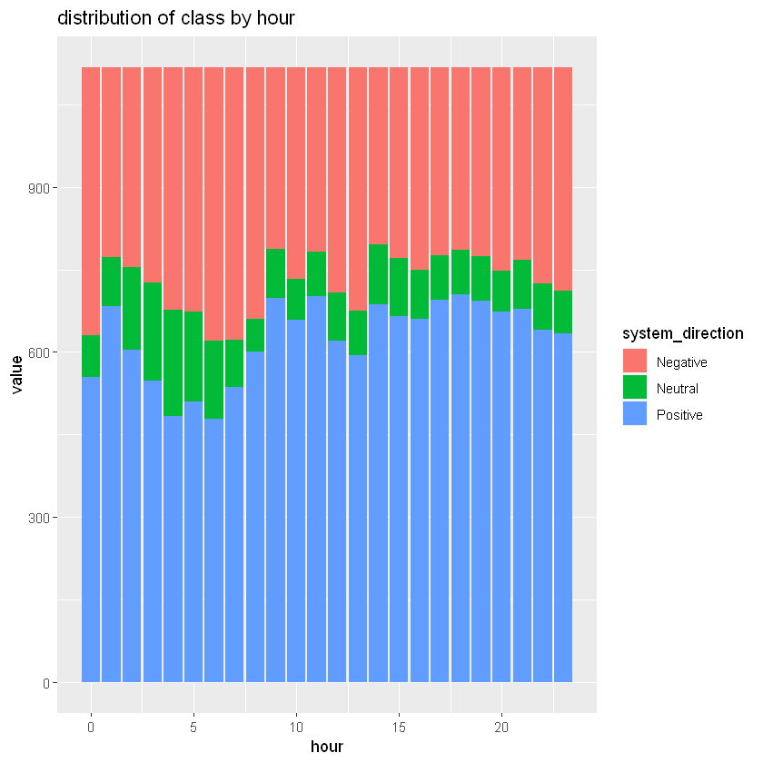

```r
plot_data = copy(data)
plot_data[,value:= 1]
plot_data[,w_day:=as.character(wday(date))]
plot_data[,mon:=as.character(month(date))]
plot_data[,trnd:= 1:.N]

ggplot(plot_data, aes(fill= system_direction,y=value, x=hour)) +
    geom_bar(position="stack", stat="identity") +
    labs(
    title = "distribution of class by hour"
    )
```

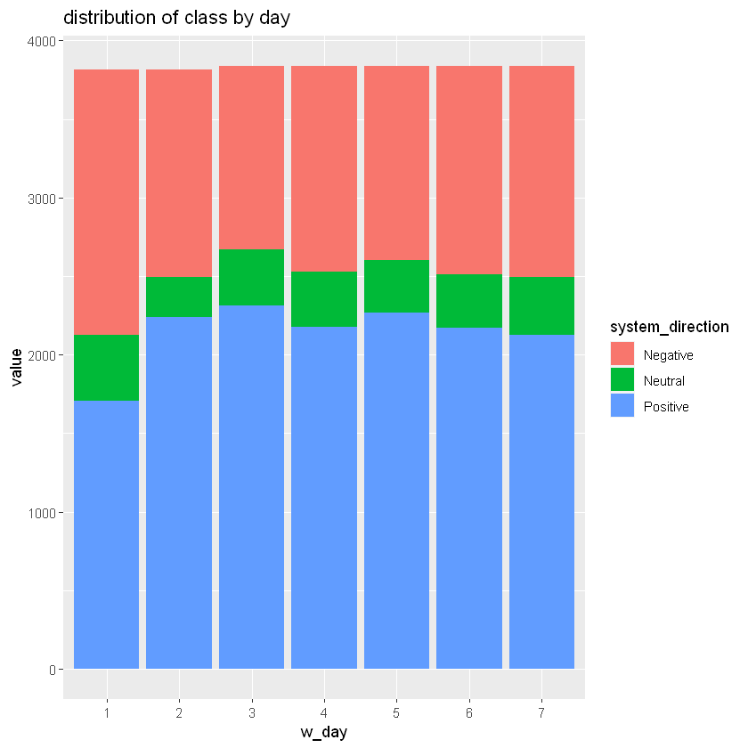

```r
ggplot(plot_data, aes(fill= system_direction,y=value, x=w_day)) +
    geom_bar(position="stack", stat="identity") +
    labs(
    title = "distribution of class by day"
    )
```

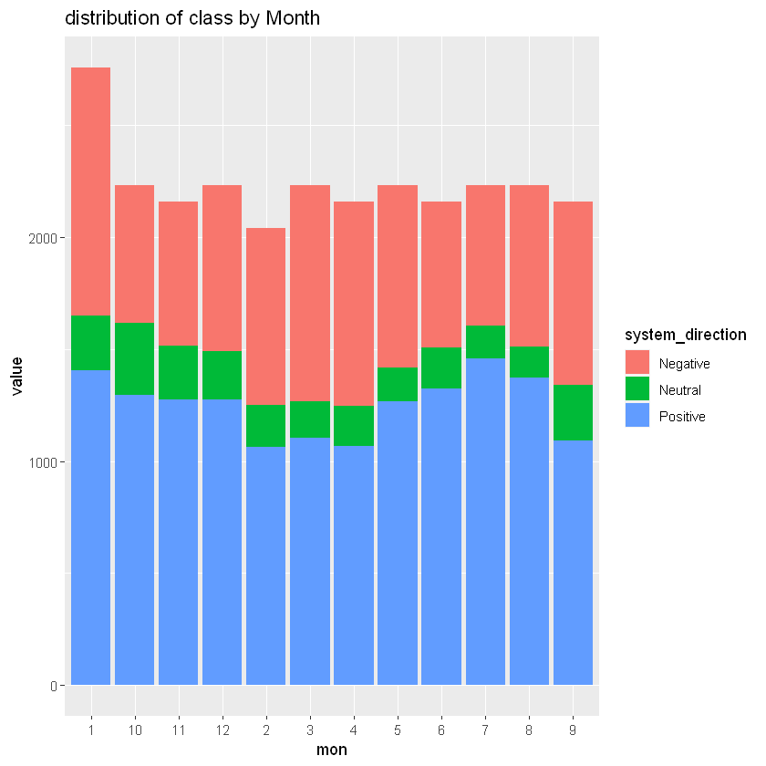

```r
ggplot(plot_data, aes(fill= system_direction,y=value, x=mon)) +
    geom_bar(position="stack", stat="identity") +
    labs(
    title = "distribution of class by Month"
    )
```

# Approach

## Time Series Representations and k-nn Classification

In this part of the project, data is represented by different time series representation techniques based on previous hours' observations. After, representation different distance approaches are used for k-nn classification.

### Methods used in Representations

**Raw Time Series Method**

First of all, In representations the last 72 hours are used to avoid computational load, however, different time span is tried to if it would be better.

the last 72 hours, the last one week and the last two weeks observations are used. And, the data is divided into hours to avoid autocorelation between consecutive hours.

```r
# to obtain different time series length the function below is recorded to avoid to much code. And representations is recorded to use different part of the project.

raw_time_series= function(rep,data_length,data){
tmp = copy(data)
for (j in c(12:23)){
if (data_length > 72){
for( i in 73:data_length){
    tmp[, sprintf("hour_%s",i) := shift(net, i)]
}
matrix = tmp[(id > data_length) & hour == j, 5:ncol(tmp)]
}

matrix = tmp[hour == j & id > data_length, 5:ncol(tmp)]

file_name = sprintf('%s_time%s_%s', rep, data_length,j)
fwrite(matrix,sprintf('%s/representations/%s.csv',getwd(),file_name),col.names=F)
loginfo("%s is created.",file_name)
}
}
```

```r
raw_time_series("raw",72,data)
raw_time_series("raw",24*7,data)
raw_time_series("raw",24*7*2,data)
```

**Piecewise Models**

Secondly, different Piecewise models: Rpart representation, piecewise linear approximation, and sax representation are used based on last 72 hours.

*Rpart Representation*

In rpart representation different maxdepth paramaters are tried to get best representation. And, the data divided into hours to avoid autocorelation between consecutive hours. The last five hours is not clear beacuse of the nature of data at 12 p.m. and after the 12 p.m. the predictions starts and the data is not recorded. Therefore, this observations are removed for representations.

```r
# The function below can represent data based on different maxdepth paramaters and record them.
rpart_representation = function(rep,maxdepth,data){
for (j in c(12:23)){

traindata = data[hour == j, 4:ncol(data)]
traindata = traindata[id>72]
long_train=melt(traindata,id.vars=c('id','system_direction'))
long_train$variable = as.character(long_train$variable)
long_train[,time:=as.numeric(gsub("hour_", "", variable))]
long_train=long_train[,list(id,system_direction,time,value)]
long_train=long_train[order(id,time)]


representation = as.data.table(t((j-6):72))

for ( i in unique(traindata$id)){
df = long_train[time > (j-7) & id==i]
# set parameters and represent data
tree_fit=rpart(value~time,df,control=rpart.control(maxdepth=maxdepth))
df [,tree_rep:=predict(tree_fit,df)]
# change actual variables with representation
representation = rbind(representation,t(df$tree_rep))
}

file_name = sprintf('%s_maxdepth%s_%s', rep, maxdepth,j)
fwrite(representation[-1,],sprintf('%s/representations/%s.csv',getwd(),file_name),col.names=F)
loginfo("%s is created.",file_name)
}
}
```

The 3,5, and 10 set as paramater of maxdepth.

```r
rpart_representation("rpart",3,data)
rpart_representation("rpart",5,data)
rpart_representation("rpart",10,data)
```

*Piecewise Linear Approximation*

In PLA representation different number of important points paramaters are tried to get best representation. And, the data divided into hours to avoid autocorelation between consecutive hours.The last five hours is not clear beacuse of the nature of data at 12 p.m. and after the 12 p.m. the predictions starts and the data is not recorded. Therefore, this observations removed for representations.

```r
# The function below can represent data based on different number of important points paramaters and record them.
pla_representation = function(rep,nimportant,data){
for (j in c(12:23)){

traindata = data[hour == j, 4:ncol(data)]
traindata = traindata[id > 72]
long_train=melt(traindata,id.vars=c('id','system_direction'))
long_train$variable = as.character(long_train$variable)
long_train[,time:=as.numeric(gsub("hour_", "", variable))]
long_train=long_train[,list(id,system_direction,time,value)]
long_train=long_train[order(id,time)]
representation = as.data.table(t((j-6):72))


for ( i in unique(traindata$id)){
 df = long_train[time > (j-7) & id==i]
 data_ts = df$value
 pla_rep=repr_pla(data_ts, times = nimportant, return = "both")
 setnames(pla_rep,c('places','points'),c('time','pla_rep'))
 pla_rep$time=pla_rep$time+(j-7 +1)

 df=merge(df,pla_rep,by='time',all.x=T)
 df[, pla_rep := na.approx(pla_rep)]

representation = rbind(representation,t(df$pla_rep))
}

 file_name = sprintf('%s_nimportant%s_%s', rep, nimportant,j)
 print(file_name)
 fwrite(representation[-1,],sprintf('%s/representations/%s.csv',getwd(),file_name),col.names=F)
 loginfo("%s is created.",file_name)
}
}
```

The 3,5, and 10 set as paramater of number of important points.

```r
pla_representation("pla",3,data)
pla_representation("pla",5,data)
pla_representation("pla",10,data)
```

*SAX representation*

In SAX representation different segment lengths and alphabet size paramaters are tried to get best representation. And, the data divided into hours to avoid autocorelation between consecutive hours.The last five hours is not clear beacuse of the nature of data at 12 p.m. and after the 12 p.m. the predictions starts and the data is not recorded. Therefore, this observations are removed for representations.

```r
# The function below can represent data based on different alpahabet size and segment length paramaters and record them.
sax_representation = function(rep, sax_segment_length=4,sax_alphabet_size=5,data){
for (j in c(12:23)){

traindata = data[hour == j, 4:ncol(data)]
traindata = traindata[id > 72]
long_train=melt(traindata,id.vars=c('id','system_direction'))
long_train$variable = as.character(long_train$variable)
long_train[,time:=as.numeric(gsub("hour_", "", variable))]
long_train=long_train[,list(id,system_direction,time,value)]
long_train=long_train[order(id,time)]
representation = as.data.table(t((j-6):72))


for ( i in unique(traindata$id)){
 df = long_train[time > (j-7) & id==i]
 data_ts = df$value
sax_rep=repr_sax(data_ts, q = sax_segment_length, a = sax_alphabet_size)
sax_rep
dummy_time=c(1:(length(sax_rep)-1))*sax_segment_length
dummy_time=c(dummy_time,length(data_ts))
dummy_time = dummy_time + (j-7)

dt_sax=data.table(time=dummy_time,sax_rep_char=sax_rep)
df=merge(df,dt_sax,by='time',all.x=T)
dt_sax=data.table(time=dummy_time,sax_rep_char=sax_rep)
df[,sax_rep_char_num:=nafill(as.numeric(as.factor(sax_rep_char)),'nocb')] # from data.table
df[,sax_rep:=mean(value),by=list(sax_rep_char_num)]

representation = rbind(representation,t(df$sax_rep))
}

 file_name = sprintf('%s_segmenthlength%sapphabetsize%s_%s', rep,sax_segment_length,sax_alphabet_size ,j)
 print(file_name)
 fwrite(representation[-1,],sprintf('%s/representations/%s.csv',getwd(),file_name),col.names=F)
 loginfo("%s is created.",file_name)
}
}
```

As segmenth length paramater 6 and 12 are set, and for alpahabet size paramater 3 and 5 are set.

```r
sax_representation("sax",6,5,data)
sax_representation("sax",12,5,data)
sax_representation("sax",6,3,data)
sax_representation("sax",12,3,data)
```

**Alternative Representations**

*Alternative Approach 1*

As an alternative approaches, the positive class is repsented by 1, neutral represented by 0, and the negative class reperented by -1 based on last 72 hours.

```r
df_alternative = copy(data[,c("date","hour","net","system_direction")])
df_alternative[,id:= 1:.N]
df_alternative[system_direction == "Positive"]$net = 1
df_alternative[system_direction == "Negative"]$net = -1
df_alternative[system_direction == "Neutral"]$net = 0


for( i in 1:72){
    df_alternative[, sprintf("hour_%s",i) := shift(net, i)]
}
tail(df_alternative)
```

A data.table: 6 × 77

| date <date> | hour <int> | net <dbl> | system_direction <fct> | id <int> | hour_1 <dbl> | hour_2 <dbl> | hour_3 <dbl> | hour_4 <dbl> | hour_5 <dbl> | ⋯ | hour_63 <dbl> | hour_64 <dbl> | hour_65 <dbl> | hour_66 <dbl> | hour_67 <dbl> | hour_68 <dbl> | hour_69 <dbl> | hour_70 <dbl> | hour_71 <dbl> | hour_72 <dbl> |
| --- | --- | --- | --- | --- | --- | --- | --- | --- | --- | --- | --- | --- | --- | --- | --- | --- | --- | --- | --- | --- |
| 2022-01-22 | 18 | 1 | Positive | 26827 | 1 | 1 | 1 | 1 | 1 | ⋯ | 1 | 0 | 1 | -1 | 1 | 1 | 1 | 1 | 1 | 1 |
| 2022-01-22 | 19 | 1 | Positive | 26828 | 1 | 1 | 1 | 1 | 1 | ⋯ | -1 | 1 | 0 | 1 | -1 | 1 | 1 | 1 | 1 | 1 |
| 2022-01-22 | 20 | 1 | Positive | 26829 | 1 | 1 | 1 | 1 | 1 | ⋯ | 1 | -1 | 1 | 0 | 1 | -1 | 1 | 1 | 1 | 1 |
| 2022-01-22 | 21 | 1 | Positive | 26830 | 1 | 1 | 1 | 1 | 1 | ⋯ | 1 | 1 | -1 | 1 | 0 | 1 | -1 | 1 | 1 | 1 |
| 2022-01-22 | 22 | 1 | Positive | 26831 | 1 | 1 | 1 | 1 | 1 | ⋯ | -1 | 1 | 1 | -1 | 1 | 0 | 1 | -1 | 1 | 1 |
| 2022-01-22 | 23 | 1 | Positive | 26832 | 1 | 1 | 1 | 1 | 1 | ⋯ | 1 | -1 | 1 | 1 | -1 | 1 | 0 | 1 | -1 | 1 |

```r
for (j in c(12:23)){

matrix = df_alternative[hour == j & id > 72, 6:ncol(df_alternative)]

file_name = sprintf('classrep_time72_%s',j)
fwrite(matrix,sprintf('%s/representations/%s.csv',getwd(),file_name),col.names=F)
loginfo("%s is created.",file_name)
}
```

*Alternative Approach 2*

As another alternative, the raw time series are used as standardized form.

```r
# The raw time series representations readed from representations file.
file_path = sprintf('%s\\representations\\', getwd())
file_names = list.files(file_path, full.names=T)
approaches = list.files(file_path, full.names=F)
raw_rep = as.logical(c(1:length(file_names)))
for ( i in 1:length(file_names)){
 raw_rep[i]= grepl('raw_time72', file_names[i])

}
file_names= file_names[raw_rep]
approaches = approaches[raw_rep]
```

```r
for (j in c(1:length(file_names))){

df_alternative_2 = fread(file_names[j])
approach = approaches[j]
file_name = sprintf("standard%s",strsplit(approach,".c")[[1]][1])
matrix = as.matrix(df_alternative_2[,-1])
scaled_matrix = t(apply(matrix,1, function(x) (x - mean(x))/ sd(x)))

fwrite(scaled_matrix,sprintf('%s/representations/%s.csv',getwd(),file_name),col.names=F)
loginfo("%s is created.",file_name)
}
```

## Methods used in classification

In this part of the project, the data is classified by using k-nn classification method in different k values and different distance calculation methods. And, evaluation of methods are based on average accuarcy which calculated by using cross-validation technique.

```r
# k-nn classification function
nn_classify_cv=function(dist_matrix,train_class,test_indices,k=1){

    test_distances_to_train=dist_matrix[test_indices,]
    test_distances_to_train=test_distances_to_train[,-test_indices]
    train_class=train_class[-test_indices]

    ordered_indices=apply(test_distances_to_train,1,order)
    if(k==1){
        nearest_class=train_class[as.numeric(ordered_indices[1,])]
        nearest_class=data.table(id=test_indices,nearest_class)
    } else {
        nearest_class=apply(ordered_indices[1:k,],2,function(x) {train_class[x]})
        nearest_class=data.table(id=test_indices,t(nearest_class))
    }

    long_nn_class=melt(nearest_class,'id')

    class_counts=long_nn_class[,.N,list(id,value)]
    class_counts[,predicted_prob:=N/k]
    wide_class_prob_predictions=dcast(class_counts,id~value,value.var='predicted_prob')
    wide_class_prob_predictions[is.na(wide_class_prob_predictions)]=0
    class_predictions=class_counts[,list(predicted=value[which.max(N)]),by=list(id)]


    return(list(prediction=class_predictions,prob_estimates=wide_class_prob_predictions))

}
```

```r
# function for calculate average accuracy of each method

get_acc = function(dist_mat,nof_rep = 5,n_fold = 10, k_levels, trainclass){

cv_indices=generateCVRuns(trainclass, ntimes =nof_rep, nfold = n_fold,
                          leaveOneOut = FALSE, stratified = TRUE)

result=vector('list',nof_rep*n_fold*length(k_levels))
iter=1


    for(i in 1:nof_rep){
        this_fold=cv_indices[[i]]
        for(j in 1:n_fold){
            test_indices=this_fold[[j]]
            for(k in 1:length(k_levels)){
                current_k=k_levels[k]
                current_fold=nn_classify_cv(dist_mat,trainclass,test_indices,k=current_k)
                accuracy=sum(trainclass[test_indices]==current_fold$prediction$predicted)/length(test_indices)
                tmp=data.table(dist_approach = dist_approach,
                               hour = h ,
                               representation= representation,
                               paramater= paramater,
                               repid=i,
                               foldid=j,
                               k=current_k,
                               acc=accuracy)
                result[[iter]]=tmp
                iter=iter+1

            }

        }

    }


return (list(result))
}
```

```r
# The distance matrix are getted from representations recorded before.
file_path = sprintf('%s\\representations\\', getwd())
file_names = list.files(file_path, full.names=T)
approaches = list.files(file_path, full.names=F)
```

**Euclidian Distance**

The distance between two time series is calculated based on observations belong the same time.

```r
for (m in (1:length(approaches))){
dist_approach = "euc"
approach = approaches[m]
representation = strsplit(approach,"_")[[1]][1]
paramater = strsplit(approach,"_")[[1]][2]
h = strsplit(strsplit(approach,"_")[[1]][3],".c")[[1]][1]
df = fread(file_names[m])



if (representation == "raw"){

    if (paramater == "time72"){
    tmp = data[id > 72 & hour == h ]
    dist_matrix = as.matrix(dist(df[1:nrow(tmp),-1]))
    diag(dist_matrix) = 2*max(dist_matrix)


    }
    if (paramater == "time168"){
    tmp = data[id > 168 & hour == h ]
    dist_matrix = as.matrix(dist(df[1:nrow(tmp),-1]))
    diag(dist_matrix) = 2*max(dist_matrix)

    }
    if (paramater =="time336"){
    tmp = data[id > 336 & hour == h ]
    dist_matrix = as.matrix(dist(df[1:nrow(tmp),-1]))
    diag(dist_matrix) = 2*max(dist_matrix)

    }
}
if (representation != "raw"){
    tmp = data[id > 72 & hour == h ]
    dist_matrix = as.matrix(dist(df[1:nrow(tmp)]))
    diag(dist_matrix) = 2*max(dist_matrix)

}


file_name = sprintf('%s_%s_%s_%s', dist_approach,representation,paramater,h)
fwrite(dist_matrix,sprintf('%s/distances/%s.csv',getwd(),file_name),col.names=F)
loginfo("%s is calculated.",file_name)

}
```

Since, the lcss, erp, and dtw distances process need many calculation in this distance calculations , last two months of data is used.

```r
for (m in (1:length(approaches))){
dist_approach = "lcss-epsilon0.5"
approach = approaches[m]
representation = strsplit(approach,"_")[[1]][1]
paramater = strsplit(approach,"_")[[1]][2]
h = strsplit(strsplit(approach,"_")[[1]][3],".c")[[1]][1]
df = fread(file_names[m])

tmp = data[hour == h & date >= "2021-11-01"]

if (representation == "raw"){

    dist_matrix = as.matrix(TSDatabaseDistances(df[(nrow(df)-nrow(tmp)+1):nrow(df),-1],distance='lcss',epsilon=0.05))
    diag(dist_matrix) = 2*max(dist_matrix)

}
if (representation != "raw"){
    dist_matrix = as.matrix(TSDatabaseDistances(df[(nrow(df)-nrow(tmp)+1):nrow(df)],distance='lcss',epsilon=0.05))
    diag(dist_matrix) = 2*max(dist_matrix)

}


file_name = sprintf('%s_%s_%s_%s', dist_approach,representation,paramater,h)
fwrite(dist_matrix,sprintf('%s/distances/%s.csv',getwd(),file_name),col.names=F)
loginfo("%s is calculated.",file_name)

}
```

**erp distance with g= 0.5**

```r
for (m in (1:length(approaches))){
dist_approach = "erp-g0.5"
approach = approaches[m]
representation = strsplit(approach,"_")[[1]][1]
paramater = strsplit(approach,"_")[[1]][2]
h = strsplit(strsplit(approach,"_")[[1]][3],".c")[[1]][1]
df = fread(file_names[m])

 tmp = data[hour == h & date >= "2021-11-01"]

if (representation == "raw"){

    dist_matrix = as.matrix(TSDatabaseDistances(df[(nrow(df)-nrow(tmp)+1):nrow(df),-1],distance='erp',g=0.5))
    diag(dist_matrix) = 2*max(dist_matrix)

}
if (representation != "raw"){

    dist_matrix = as.matrix(TSDatabaseDistances(df[(nrow(df)-nrow(tmp)+1):nrow(df)],distance='erp',g=0.5))
    diag(dist_matrix) = 2*max(dist_matrix)

}


file_name = sprintf('%s_%s_%s_%s', dist_approach,representation,paramater,h)
fwrite(dist_matrix,sprintf('%s/distances/%s.csv',getwd(),file_name),col.names=F)
loginfo("%s is calculated.",file_name)

}
```

**dtw distance**

```r
for (m in (1:length(file_names))){
dist_approach = "dtw"
approach = approaches[m]
representation = strsplit(approach,"_")[[1]][1]
paramater = strsplit(approach,"_")[[1]][2]
h = strsplit(strsplit(approach,"_")[[1]][3],".c")[[1]][1]
df = fread(file_names[m])

tmp = data[ hour == h & date >= "2021-11-01"]

if (representation == "raw"){


    dist_matrix = as.matrix(dtwDist(df[(nrow(df)-nrow(tmp)+1):nrow(df),-1]))

}
if (representation != "raw"){
    dist_matrix = as.matrix(dtwDist(df[(nrow(df)-nrow(tmp)+1):nrow(df)]))

}

diag(dist_matrix) = 2*max(dist_matrix)


file_name = sprintf('%s_%s_%s_%s', dist_approach,representation,paramater,h)
fwrite(dist_matrix,sprintf('%s/distances/%s.csv',getwd(),file_name),col.names=F)
loginfo("%s is calculated.",file_name)

}
```

**Classification and Evaluation of Train Data**

Diffrent representation models and distance approaches are used to classify time series. In this part of study, every approach will be used for k-nn classification model with k = 1,3,5 values. The performance of each approach is evaluated based on mean accuracy and standard deaviation. The approach which has the highest mean accuracy will be used for prediction. However, every hour is evaluated as diffrent dataset to avoid autocorralation between sequential hours.

```r
# recorded distances readed to avoid repeat calculations
file_path = sprintf('%s\\distances\\', getwd())
file_names = list.files(file_path, full.names=T)
approaches = list.files(file_path, full.names=F)
```

```r
results = vector('list',length(file_names))
length(results)
```

720

```r
for (m in (1:length(approaches))){

approach = approaches[m]
dist_approach = strsplit(approach,"_")[[1]][1]
representation = strsplit(approach,"_")[[1]][2]
paramater = strsplit(approach,"_")[[1]][3]
h = strsplit(strsplit(approach,"_")[[1]][4],".c")[[1]][1]
dist_matrix = as.matrix(fread(file_names[m]))

if(dist_approach == "euc"){
if (representation == "raw"){

    if (paramater == "time72"){
    tmp = data[id > 72 & hour == h & date < "2022-01-09"]



    }
    if (paramater == "time168"){
    tmp = data[id > 168 & hour == h &date < "2022-01-09"]

    }
    if (paramater =="time336"){
    tmp = data[id > 336 & hour == h &date < "2022-01-09"]

    }
}
if (representation != "raw"){
    tmp = data[id > 72 & hour == h &date < "2022-01-09"]

}
}

if(dist_approach != "euc"){
tmp = data[ hour == h & date >= "2021-11-01" & date < "2022-01-09"]
}





dist_matrix = dist_matrix[1:nrow(tmp),1:nrow(tmp)]
tmp_train_class = tmp$system_direction
k_levels = c(1,3,5)
tmp_train = get_acc(dist_mat =dist_matrix,k_levels= k_levels,trainclass = tmp_train_class)
tmp_train  = rbindlist(tmp_train[[1]])
results[[m]] = tmp_train[,list(avg_acc=mean(acc),sdev_acc=sd(acc),result_count=.N),by=list(hour,dist_approach,representation,paramater,k)]
loginfo("%s by k-nn classification accuracies are calculated.",approach)

}
```

```r
overall_results = rbindlist(results)
overall_results[order(hour,avg_acc,-sdev_acc)]
```

A data.table: 2160 × 8

| hour <chr> | dist_approach <chr> | representation <chr> | paramater <chr> | k <dbl> | avg_acc <dbl> | sdev_acc <dbl> | result_count <int> |
| --- | --- | --- | --- | --- | --- | --- | --- |
| 12 | lcss-epsilon0.5 | raw | time168 | 1 | 0.2209524 | 0.11074445 | 50 |
| 12 | lcss-epsilon0.5 | raw | time168 | 3 | 0.2766667 | 0.12450002 | 50 |
| 12 | lcss-epsilon0.5 | raw | time168 | 5 | 0.2823810 | 0.12478961 | 50 |
| 12 | lcss-epsilon0.5 | pla | nimportant3 | 3 | 0.3314286 | 0.12770648 | 50 |
| 12 | lcss-epsilon0.5 | rpart | maxdepth5 | 3 | 0.3533333 | 0.16007079 | 50 |
| 12 | lcss-epsilon0.5 | sax | segmenthlength12apphabetsize5 | 3 | 0.3695238 | 0.12963067 | 50 |
| 12 | lcss-epsilon0.5 | rpart | maxdepth3 | 3 | 0.3723810 | 0.15828282 | 50 |
| 12 | lcss-epsilon0.5 | sax | segmenthlength12apphabetsize3 | 3 | 0.3761905 | 0.14502725 | 50 |
| 12 | lcss-epsilon0.5 | rpart | maxdepth10 | 3 | 0.3761905 | 0.18081679 | 50 |
| 12 | lcss-epsilon0.5 | sax | segmenthlength6apphabetsize3 | 3 | 0.3771429 | 0.13079636 | 50 |
| 12 | lcss-epsilon0.5 | sax | segmenthlength6apphabetsize5 | 3 | 0.3819048 | 0.14414387 | 50 |
| 12 | lcss-epsilon0.5 | pla | nimportant3 | 5 | 0.3842857 | 0.13520226 | 50 |
| 12 | lcss-epsilon0.5 | sax | segmenthlength12apphabetsize3 | 5 | 0.3847619 | 0.14648456 | 50 |
| 12 | lcss-epsilon0.5 | sax | segmenthlength6apphabetsize3 | 5 | 0.3857143 | 0.13545788 | 50 |
| 12 | lcss-epsilon0.5 | classrep | time72 | 1 | 0.3938095 | 0.18618900 | 50 |
| 12 | lcss-epsilon0.5 | sax | segmenthlength6apphabetsize5 | 5 | 0.3942857 | 0.15363912 | 50 |
| 12 | lcss-epsilon0.5 | sax | segmenthlength12apphabetsize5 | 5 | 0.3952381 | 0.15430335 | 50 |
| 12 | lcss-epsilon0.5 | rpart | maxdepth5 | 5 | 0.4119048 | 0.16720377 | 50 |
| 12 | lcss-epsilon0.5 | rpart | maxdepth10 | 5 | 0.4161905 | 0.17418420 | 50 |
| 12 | lcss-epsilon0.5 | rpart | maxdepth3 | 5 | 0.4238095 | 0.16305258 | 50 |
| 12 | lcss-epsilon0.5 | standardraw | time72 | 3 | 0.4566667 | 0.16359731 | 50 |
| 12 | lcss-epsilon0.5 | pla | nimportant10 | 3 | 0.4580952 | 0.18452561 | 50 |
| 12 | lcss-epsilon0.5 | pla | nimportant5 | 3 | 0.4666667 | 0.15355175 | 50 |
| 12 | lcss-epsilon0.5 | standardraw | time72 | 1 | 0.4728571 | 0.16439589 | 50 |
| 12 | euc | pla | nimportant3 | 1 | 0.4839492 | 0.03821228 | 50 |
| 12 | euc | pla | nimportant10 | 1 | 0.4902670 | 0.05046977 | 50 |
| 12 | lcss-epsilon0.5 | standardraw | time72 | 5 | 0.4914286 | 0.15255093 | 50 |
| 12 | lcss-epsilon0.5 | classrep | time72 | 3 | 0.4919048 | 0.15170297 | 50 |
| 12 | lcss-epsilon0.5 | pla | nimportant10 | 5 | 0.4933333 | 0.17243523 | 50 |
| 12 | euc | pla | nimportant5 | 1 | 0.4939443 | 0.04500953 | 50 |
| ⋮ | ⋮ | ⋮ | ⋮ | ⋮ | ⋮ | ⋮ | ⋮ |
| 23 | lcss-epsilon0.5 | sax | segmenthlength12apphabetsize3 | 5 | 0.6095238 | 0.12690312 | 50 |
| 23 | lcss-epsilon0.5 | sax | segmenthlength6apphabetsize5 | 5 | 0.6095238 | 0.12690312 | 50 |
| 23 | euc | raw | time168 | 1 | 0.6118582 | 0.04036765 | 50 |
| 23 | dtw | raw | time168 | 5 | 0.6138095 | 0.14513012 | 50 |
| 23 | lcss-epsilon0.5 | rpart | maxdepth10 | 5 | 0.6142857 | 0.11554618 | 50 |
| 23 | lcss-epsilon0.5 | sax | segmenthlength12apphabetsize5 | 5 | 0.6142857 | 0.11554618 | 50 |
| 23 | lcss-epsilon0.5 | raw | time72 | 5 | 0.6147619 | 0.11257322 | 50 |
| 23 | lcss-epsilon0.5 | pla | nimportant3 | 5 | 0.6152381 | 0.10309658 | 50 |
| 23 | lcss-epsilon0.5 | pla | nimportant5 | 5 | 0.6152381 | 0.09897433 | 50 |
| 23 | lcss-epsilon0.5 | raw | time336 | 5 | 0.6180952 | 0.10383457 | 50 |
| 23 | lcss-epsilon0.5 | sax | segmenthlength6apphabetsize3 | 5 | 0.6190476 | 0.10271884 | 50 |
| 23 | lcss-epsilon0.5 | classrep | time72 | 5 | 0.6209524 | 0.08709609 | 50 |
| 23 | dtw | raw | time168 | 3 | 0.6214286 | 0.17164237 | 50 |
| 23 | euc | raw | time336 | 3 | 0.6234862 | 0.03975122 | 50 |
| 23 | lcss-epsilon0.5 | pla | nimportant10 | 5 | 0.6261905 | 0.10342038 | 50 |
| 23 | dtw | standardraw | time72 | 3 | 0.6266667 | 0.15760012 | 50 |
| 23 | dtw | raw | time72 | 5 | 0.6323810 | 0.11516105 | 50 |
| 23 | euc | raw | time336 | 5 | 0.6370642 | 0.03580453 | 50 |
| 23 | erp-g0.5 | raw | time72 | 5 | 0.6428571 | 0.11423711 | 50 |
| 23 | euc | raw | time168 | 3 | 0.6516214 | 0.04410679 | 50 |
| 23 | euc | raw | time72 | 1 | 0.6605012 | 0.05158847 | 50 |
| 23 | dtw | classrep | time72 | 3 | 0.6614286 | 0.17042751 | 50 |
| 23 | euc | raw | time168 | 5 | 0.6662035 | 0.03983200 | 50 |
| 23 | dtw | classrep | time72 | 5 | 0.6780952 | 0.18375156 | 50 |
| 23 | euc | classrep | time72 | 1 | 0.6846765 | 0.03822226 | 50 |
| 23 | dtw | classrep | time72 | 1 | 0.6866667 | 0.17806764 | 50 |
| 23 | euc | raw | time72 | 3 | 0.7015446 | 0.04859531 | 50 |
| 23 | euc | classrep | time72 | 3 | 0.7179115 | 0.03824131 | 50 |
| 23 | euc | raw | time72 | 5 | 0.7244357 | 0.04706470 | 50 |
| 23 | euc | classrep | time72 | 5 | 0.7346126 | 0.04182468 | 50 |

```r
best_results = data.table(t(1:8))
for (i in 12:23){
best_results = rbind(best_results,(head(overall_results[order(-avg_acc,sdev_acc)][hour ==i],1)),use.names = FALSE)
}
```

*Overall Accuracy*

```r
mean(best_results$avg_acc)
```

[output not shown]